# LANDFIRE-powered ecosystem assessment

Green Mountain National Forest, Vermont

Randy Swaty (with R code from Myles Walimaa)

2022-06-03

## Introduction and goals

This document showcases LANDFIRE-powered maps and charts for the Green Mountain National Forest in Vermont. In general LANDFIRE enables an assessment of past and present ecosystems and their disturbances plus the ability to make comparisons. LANDFIRE does not address climate change, or set “Desired Future Conditions”.

exploring potential impacts of climate change and how management actions may or may not lead to desired future conditions may be accomplished using [SyncroSim](https://syncrosim.com/) and [TNC’s modeling site](https://thenatureconservancy.github.io/landfiremodels/index.html) for more information.

Due to the name and major funding sources LANDFIRE is often thought of as a fire dataset. While LANDFIRE does deliver many fire-focused datasets (e.g., the 40 Scott and Bergan Fire Behavior Fuel Models. Visit [here](https://landfire.gov/fbfm40.php)) for more information], this assessment is focused on the vegetation datasets.

Additionally-this document is meant to be a conversation starter, and does not include the many possibilities brought to the table by NIACS for example.

## A few characterisitics of LANDFIRE data and this report

LANDFIRE products are designed for use on large areas, typically comparing watersheds to watersheds for example. Often users ask “how small of an area can we use LANDFIRE data?” which is a tough question to answer as it varies based on data quality, heterogeneity of the vegetation (and underlying driving factors such as soils), and the particular dataset(s) being considered. Further, the purpose of data use is of particular importance. Using the data to explore trends is one thing, using LANDFIRE (or any data for that matter) to make place-specific decisions is another.

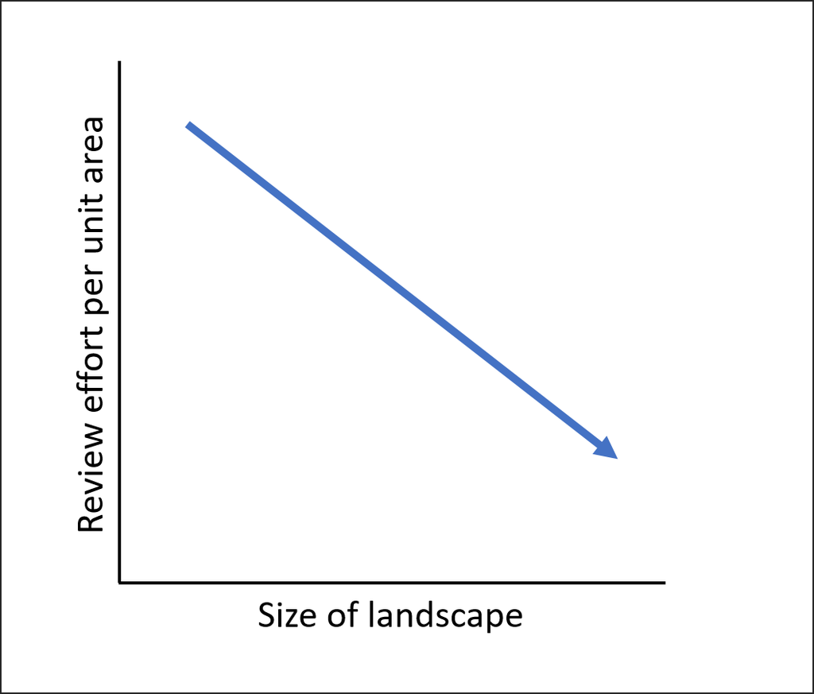

Schematic illustrating need for more review of data for smaller landscapes.

LANDFIRE data has been successfully used for mid-scale planning (~10k acres), but that was after considerable review by experts. To use data for smaller areas or for more detailed decision making requires more review per unit area (see graphic in sidebar).

LANDFIRE spatial data is delivered in raster format with 30m pixel size. Attribute tables can range from fairly simple (e.g., Existing Vegetation Cover), to rich with many fields (e.g., the Biophysical Settings data which includes historical fire regime information).

This report was created using free data and software. Data was downloaded from https://landfire.gov/getdata.php, all GIS processing and charts created in R, and all maps created in Quantum GIS.

[R](https://www.r-project.org/)

[QGIS](https://www.qgis.org/en/site/)

The report itself was written as an R-Markdown document.

Learn more about r-markdown documents [here.](https://rmarkdown.rstudio.com/)

It is not necessary to use these tools! One could just as easily use ESRI and Microsoft products.

## Which ecosystems were dominant prior to European Colonization?

With climate change, invasive exotic species, resource extraction and other modern ecosystem drivers it can be difficult to develop a baseline, or understanding of what was on the landscape prior to European colonization. LANDFIRE has a product suite under the Biophysical Settings (BpS) label that includes three components. The **BpS Descriptions** and accompanying **state-and-transition models**. These documents and models describe how over 900 BpSs of the U.S. *looked and worked* historically. Each one includes a description of the major succession classes, and estimated amounts of each succession class based on natural disturbance regimes. Learn more about these products and their development by reading [Blankenship et al. (2021)](https://esajournals.onlinelibrary.wiley.com/doi/pdf/10.1002/ecs2.3484).

LANDFIRE defines Biophysical Settings as “the vegetation system that may have been dominant on the landscape prior to Euro-American settlement and is based on both the current biophysical environment and an approximation of the historical disturbance regime”

find yours at [here](https://landfirereview.org/search.php)

download from [this site](https://landfire.gov/bps-models.php)

Also included are the **BpS spatial data**. This raster data includes a robust attribute table with information on historical fire regimes in addition to multiple classifications of the BpSs (e.g., there are lumped schemes).

learn more [here](https://landfire.gov/bps.php)

**Green Mountain NF dominated by Northern Hardwood Forests historically**

Based on LANDFIRE BpS data three BpSs were present on over 90% of the landscape as shown in the chart and map below. Both graphics are not complete-there are more BpSs mapped than indicated on both. Lists were shortened for clarity, and to remove possible noise. A complete list and mapped amounts are available from the author.

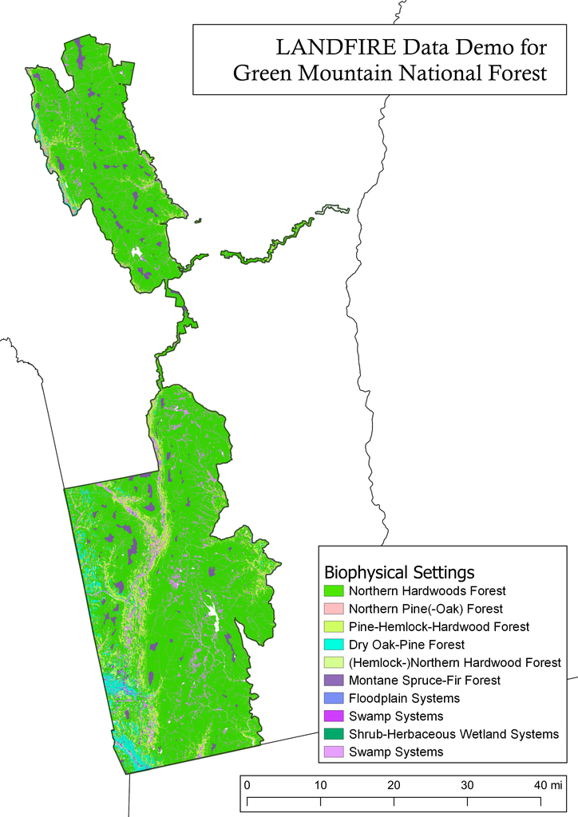